# Seoul Bike Sharing Demand

STAT 420, Summer 2022, Scott Downey, Sushma Ponna, William Shih

# 1 Introduction

Rental bikes and bike sharing are important in urban cities as bikes reduce traffic congestion, reduce air pollution, and improve last mile transportation. Bikes will become even more important in the future as cities urbanize and have high population densities. The goal of this project is to build a model that will accurately predict the volume of bike rentals at a given time. Predicting exactly many bikes to provide makes sure that there will be no shortage of bikes that would result in people waiting for a bike yet also not have a large surplus of bikes as that would be a waste of resources.

The data set contains bike sharing data in Seoul from 12/1/2017 to 11/30/2018. Each observation represents an hour of time. The variable of interest for prediction is the rented bike count for the hour. The 12 variables that will be considered as predictors include the hour of day, temperature, humidity, wind speed, visibility, dew point, solar radiation, rainfall, snowfall, season of year, holiday (boolean), and functioning (boolean). The dataset is associated with two papers published in a journal in February and March 2020 related to gradient tree boosting, but here we’ll be only using linear regression. and is found at the Seoul government website http://data.seoul.go.kr/

A further description of the dataset can be found at https://archive.ics.uci.edu/ml/datasets/Seoul+Bike+Sharing+Demand

# 2 Methods

We began by importing and cleaning the raw data from the dataset described above. As part of this, we transformed several predictors into Factor and Integer variables. We also broke out the ‘Date’ field into ‘Day’, ‘Month’ and ‘Year’. We eventually discarded the ‘Year’ predictor, as our model will be focused on predicting usage for future years (and this will enable a ‘year agnostic’ model to predict usage regardless of yearly data).

```r
#Load the bike sharing data into R
require(dplyr)
library(tidyr)
library(ggplot2)
library(kableExtra)
colnames = c("Date","RentedBikeCount","Hour","Temperature","Humidity","Wind","Visibility",
             "DewPoint","SolarRadiation","Rainfall","Snowfall","Season","Holiday","Functional")
data = read.csv("https://archive.ics.uci.edu/ml/machine-learning-databases/00560/SeoulBikeData.csv",
                col.names = colnames)

day = substr(data$Date,1,2)
month = substr(data$Date,4,5)
Week = paste0(substr(data$Date, 7, 10), "-",month,"-",day)
Week = weekdays(as.Date(Week))

data = tibble(data)
#Separate 'Date'  into Day, Month and Year
data = separate(data, "Date", c("Day", "Month", "Year"))
#Convert predictors to factors or integers as needed
data$Season = as.factor(data$Season)
data$Holiday = as.factor(data$Holiday)
data$Functional = as.factor(data$Functional)
data$Day = as.integer(data$Day)
data$Month = as.integer(data$Month)
data$Year = as.integer(data$Year)
#Remove 'Year' as this won't be a good predictor for future years
data = dplyr::select(data, -Year)
```

We investigated the data, particularly how predictors related to each other through collinearity. Below is a correlation plot describing each. Temperature and (to a lesser degree) Humidity both had high correlation to Dewpoint.

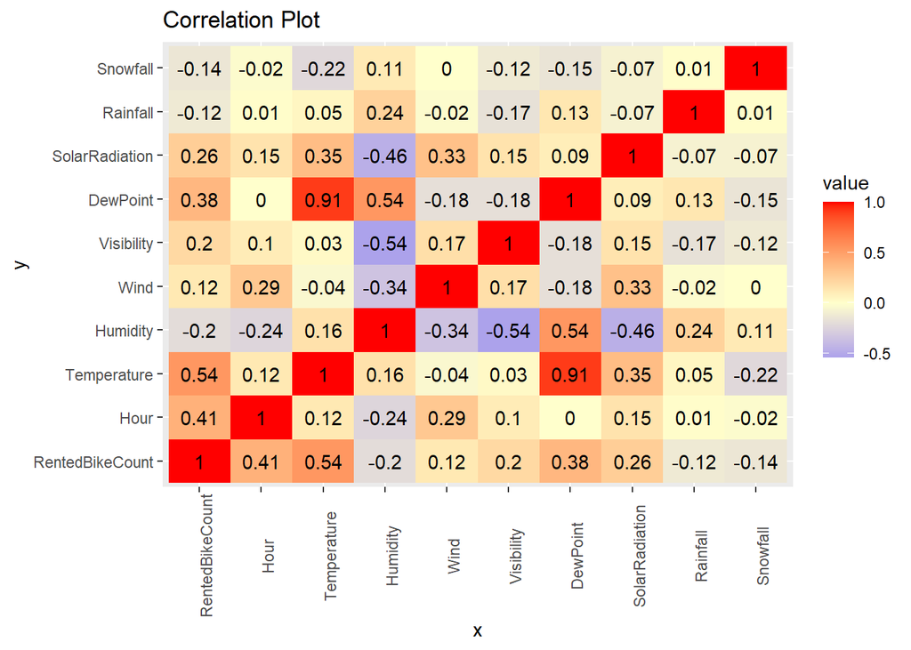

Figure 2.1: Correlation Plot of Continuous Variables

```r
correlations = round(cor(data %>% select(-c(Day, Month, Season, Holiday, Functional))), 2)
cor_melt = reshape2::melt(correlations)
ggplot(cor_melt, aes(x = Var1, y = Var2, fill = value)) +
  geom_tile() +
  theme(axis.text.x = element_text(angle = 90)) +
  xlab("x") + ylab("y") + ggtitle("Correlation Plot") +
  scale_fill_gradient2(low = "#075AFF",
                       mid = "#FFFFCC",
                       high = "#FF0000") +
  geom_label(aes(label = value), color = "black", label.size = NA)
```

We looked at the response ‘RentedBikeCount’ as it relates to the various predictors we have available. Below we compared time and date (Day, Month and Hour), as well as environment predictors like temperature, humidity, rainfall, snowfall, solar radiation, etc.

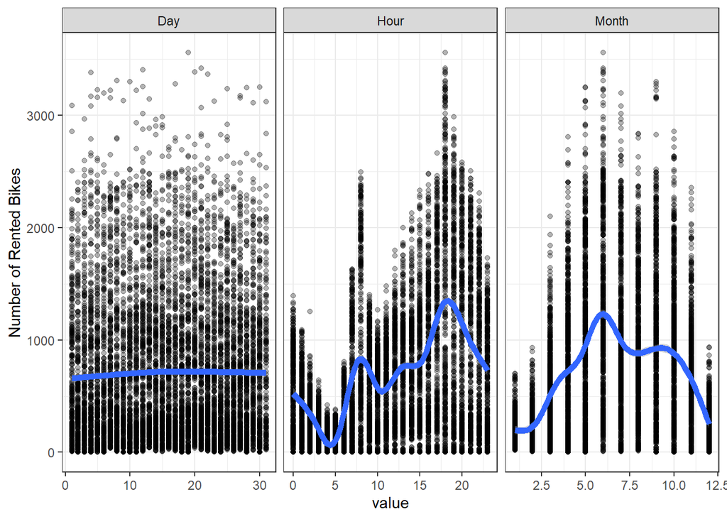

Figure 2.2: Number of Rented Bikes by Hour/Day/Month

```r
draw_plot = function(data){
  data %>%
    gather(-RentedBikeCount, key = "xaxis", value = "value") %>%
    ggplot(aes(x = value, y = RentedBikeCount)) +
    geom_point(alpha = 0.3) + theme_bw() +
    stat_smooth(geom = "smooth", size = 2, level = 0.95) + ylab("Number of Rented Bikes") +
    facet_wrap(xaxis ~ ., scales = "free_x")
}
draw_plot(data %>% select(RentedBikeCount, Hour, Day, Month))
```

```r
#Remove 'Day' as the plot shows it won't a useful predictor
data = dplyr::select(data, -Day)
```

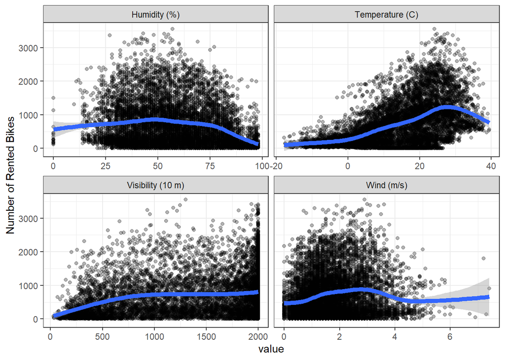

Figure 2.3: Number of Rented Bikes by Temperature/Humidity/Wind/Visilibty

```r
draw_plot(data %>% select(RentedBikeCount, Temperature, Humidity, Wind, Visibility) %>%
  rename(`Humidity (%)` = Humidity, `Temperature (C)` = Temperature, `Wind (m/s)` = Wind, `Visibility (10 m)` = Visibility))
```

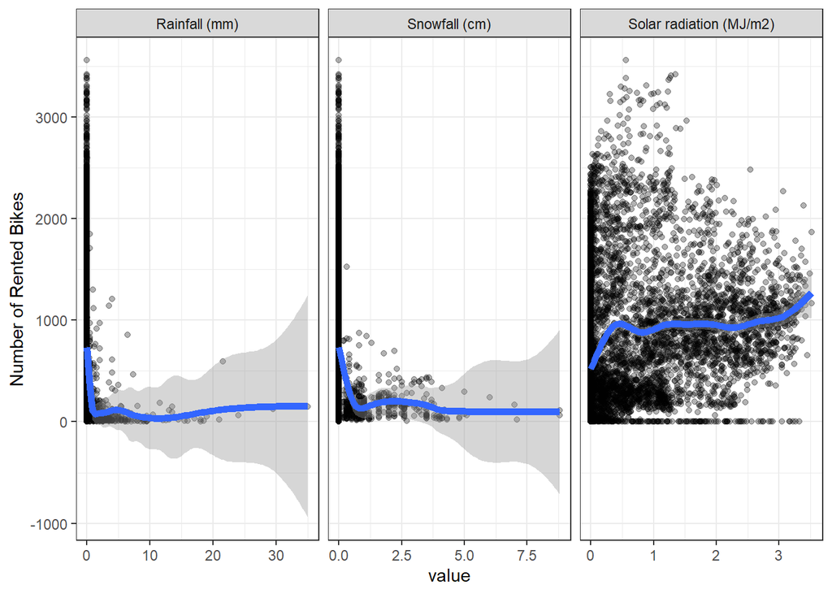

Figure 2.4: Number of Rented Bikes by Solar Radiation, Rainfall, Snowfall

```r
draw_plot(data %>% select(RentedBikeCount, SolarRadiation, Rainfall, Snowfall) %>%
  rename(`Solar radiation (MJ/m2)` = SolarRadiation, `Rainfall (mm)` = Rainfall, `Snowfall (cm)` = Snowfall))
```

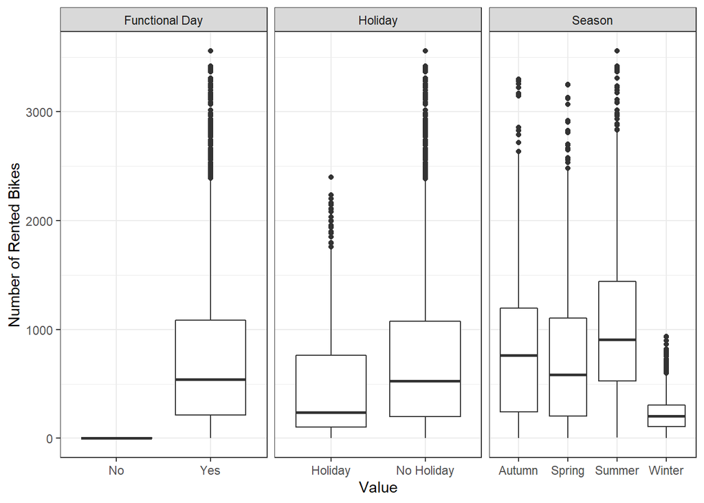

Figure 2.5: Box Plot of Rented Bikes by Season of Year, Holiday, Functional

```r
data %>%
  select(RentedBikeCount, Season, Holiday, Functional) %>%
  rename(`Functional Day` = Functional) %>%
  pivot_longer(., -RentedBikeCount, names_to = "Variable", values_to = "Value") %>%
  ggplot(aes(x = Value, y = RentedBikeCount)) + theme_bw() +
    geom_boxplot() + ylab("Number of Rented Bikes") +
    facet_wrap(. ~ Variable, scales = "free_x")
```

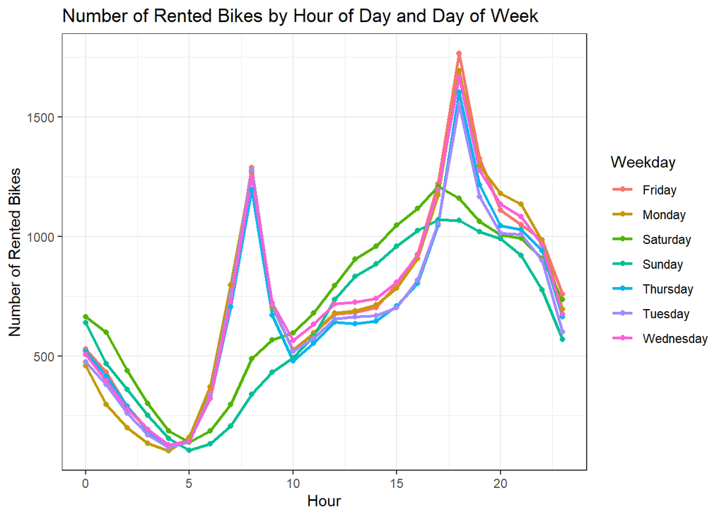

Figure 2.6: Number of Rented Bikes by Hour of Day and Day of Week

```r
bikeperweekdayhour = data.frame(Bike = data$RentedBikeCount, Hour = data$Hour, Weekday = Week) %>%
  group_by(Hour, Weekday) %>%
  summarize(Count = mean(Bike))
ggplot(bikeperweekdayhour, aes(x = Hour, y = Count, group = Weekday, color = Weekday)) +
  ylab("Number of Rented Bikes") + geom_line(size = 1) + geom_point() + theme_bw() +
  ggtitle("Number of Rented Bikes by Hour of Day and Day of Week")
```

```r
# Add Weekend as a new variable as number of rented bikes varies depending on whether it is Saturday/Sunday vs the other 5 days
data$Weekend = as.factor(ifelse(Week == "Saturday" | Week == "Sunday", 1, 0))
```

The `evaluate` function below is for generating the data for Table 3.1 and the top half of Table 3.3. The `evaluate_power` function is for generating the the data for bottom half of Table 3.3. The `get_table` formats two tables. The `transformation_power` function is for generating the data for Table 3.2. The `get_R2_helper` function is based on sklearn.metrics.r2_score. https://scikit-learn.org/stable/modules/model_evaluation.html#r2-score

```r
#Function to calculate LOOCV-RMSE
get_loocv_rmse = function(model) {
  sqrt(mean((resid(model) / (1 - hatvalues(model))) ^ 2))
}
#Function to calculate Test RMSE
get_rmse = function(model, power = 1){
  pred = predict(model, bike_tst)^power
  actual = bike_tst$RentedBikeCount
  n = length(pred)
  sqrt(1/n * sum((actual-pred)^2))
}
get_R2_helper = function(y, yhat){
  ybar = mean(y)
  1 - sum((y-yhat)^2)/sum((y-ybar)^2)
}
#Function to return R^2
get_R2 = function(model, power = 1){
  get_R2_helper(y = bike_tst$RentedBikeCount, yhat = predict(model, bike_tst)^power)
}
#Function to return Adjusted R^2
get_R2_adj = function(model, power){
  factor = summary(model)$adj.r.squared/summary(model)$r.squared
  get_R2_helper(y = bike_trn$RentedBikeCount, yhat = predict(model, bike_trn)^power)
}
#Function to evaluate the list of models with metrics chosen
evaluate = function(models, row_names){
  num_coefs = sapply(models, function(x) length(coef(x)))
  loocv_rmse = sapply(models, get_loocv_rmse)
  bics_list = unlist(sapply(models, AIC, k = log(6132)))
  rmse_list = sapply(models, get_rmse)
  R2test_list = sapply(models, get_R2)
  R2adj_list = sapply(models, function(x) summary(x)$adj.r.squared)
  frame = cbind(num_coefs, loocv_rmse, bics_list, rmse_list, R2adj_list, R2test_list)
  colnames(frame) = c("Coefficients", "LOOCV-RMSE","BIC","Test RMSE","Adjusted R2","Test R2")
  rownames(frame) = row_names
  return(frame)
}
#Function to evaluate the list of models with metrics chosen with given power transformation to y
evaluate_power = function(models, power = 0.5, row_names){
  num_coefs = sapply(models, function(x) length(coef(x)))
  loocv_rmse = sapply(models, get_loocv_rmse)
  bics_list = unlist(sapply(models, AIC, k = log(6132)))
  rmse_list = sapply(models, get_rmse, power = 1/power)
  R2test_list = sapply(models, function(model) get_R2(model, power = 1/power))
  R2adj_list = sapply(models, get_R2_adj, power = 1/power)
  frame = cbind(num_coefs, loocv_rmse, bics_list, rmse_list, R2adj_list, R2test_list)
  colnames(frame) = c("Coefficients", "LOOCV-RMSE","BIC","Test RMSE","Adjusted R2","Test R2")
  rownames(frame) = row_names
  return(frame)
}
#Function to provide data in a table format
get_table = function(frame, title){
  # Minimum for 2,3,4
  # Maximum for 5,6
  kable(frame, digits = c(0,1,1,1,3,3), caption = title, format.args = list(big.mark = ",")) %>%
    column_spec(3, bold = (frame[,2] == min(frame[,2]))) %>%
    column_spec(4, bold = (frame[,3] == min(frame[,3]))) %>%
    column_spec(5, bold = (frame[,4] == min(frame[,4]))) %>%
    column_spec(6, bold = (frame[,5] == max(frame[,5]))) %>%
    column_spec(7, bold = (frame[,6] == max(frame[,6]))) %>%
    kable_styling(bootstrap_options = c("striped", "hover", "bordered", "condensed", "responsive"))
}
#Helper function to plot diagnostics
plot_diagnostics = function(model, title){
  require(ggplot2)
  require(grid)
  require(gridExtra)
    pcol = "black"
    lcol = "dodgerblue"
    data1 = data.frame(Fitted = fitted(model), Residuals = resid(model))
    plot1 = ggplot(data1, aes(x = Fitted, y = Residuals)) +
      geom_point(alpha = 0.3, color = pcol) + theme_bw() + geom_hline(yintercept = 0, color = lcol) +
      stat_smooth() +
      ggtitle(paste("Fitted vs Residuals for\n",title))
    plot2 = ggplot(data1, aes(sample = Residuals)) +
      stat_qq(color = pcol) + stat_qq_line(color = lcol) + theme_bw() +
      xlab("Theoretical Quantiles") + ylab("Sample Quantiles") +
      ggtitle(paste("Normal Q-Q Plot for\n",title))
    arrangeGrob(plot1, plot2, nrow = 1, ncol = 2)
}
# Function to find Model Metrics in original data units given a power transformation to y
transformation_power = function(pow, form, offset){
  actual_test = bike_tst$RentedBikeCount
  train = bike_trn
  train$RentedBikeCount = train$RentedBikeCount + offset
  if (pow != 0){
    train$RentedBikeCount = train$RentedBikeCount^pow
  }
  if (pow == 0){
    train$RentedBikeCount = log(train$RentedBikeCount)
  }
  model = lm(form, data = train)
  R2_factor = summary(model)$adj.r.squared/summary(model)$r.squared
  test = bike_tst
  test$RentedBikeCount = test$RentedBikeCount + offset
  if (pow != 0){
    test$RentedBikeCount = test$RentedBikeCount^pow
  }
  if (pow == 0){
    test$RentedBikeCount = log(test$RentedBikeCount)
  }
  n = nrow(test)
  pred_test = predict(model, test)^(1/pow) - offset
  pred_train = predict(model, train)^(1/pow) - offset
  negative_values = sum(predict(model, test) < 0)/n
  if (pow == 0){
    pred_test = exp(predict(model, test)) - offset
    pred_train = exp(predict(model, train))  - offset
    negative_values = sum(predict(model, test) < 0)/n
  }
  pred_test[is.na(pred_test)] = 0
  pred_train[is.na(pred_train)] = 0
  c(Adj_R2 = cor(pred_train, bike_trn$RentedBikeCount)^2*R2_factor,
         Test_RMSE = sqrt(1/n * sum((actual_test-pred_test)^2)),
          Negative_Values = negative_values)
}
```

We then split our data into ‘Train’ and ‘Test’ data sets. We used a 70/30 split Train/Test, where we would build our model on the ‘Train’ data and test its performance on the ‘Test’ dataset.

```r
#Split data into training and test data
set.seed(42)
trn_size = as.integer(0.7 * count(data))
trn_idx = sample(nrow(data), trn_size)
bike_trn = data[trn_idx, ]
bike_tst = data[-trn_idx, ]
```

We began with several initial models - an multiple linear regressions (MLR) additive model and several interaction models, ending will a “full” interaction model with all two-way interaction between the predictors.

```r
#Initial model starting points
model_add = lm(RentedBikeCount ~ ., data = bike_trn)
model_fact0 = lm(RentedBikeCount ~ . + factor(Hour), data = bike_trn)
model_fact1 = lm(RentedBikeCount ~ . + factor(Hour)*Weekend, data = bike_trn)
model_fact2 = lm(RentedBikeCount ~ . + factor(Hour)*Weekend + (Temperature * .), data = bike_trn)
model_fact3 = lm(RentedBikeCount ~ . + factor(Hour)*Weekend + (Temperature * .) + (Hour*.), data = bike_trn)
model_fact4 = lm(RentedBikeCount ~ . + factor(Hour)*Weekend + (Temperature * .) + (Humidity*.) + (Hour*.), data = bike_trn)
model_fact5 = lm(RentedBikeCount ~ (.)^2 + factor(Hour)*Weekend, data = bike_trn)
continuous = c("Hour","Temperature","Humidity","Wind","Visibility","DewPoint","SolarRadiation","Rainfall","Snowfall")
full_formula = as.formula(
    paste0('RentedBikeCount ~ (.)^2 + factor(Hour) + ', paste0('I(',continuous,'^2)*.',collapse = ' + ')))
model_fact6 = lm(RentedBikeCount ~ (.)^2 + factor(Hour)*Weekend + I(Temperature^2)*. + I(Wind^2)*., data = bike_trn)
model_full = lm(full_formula, data = bike_trn)
models = list(model_add, model_fact0, model_fact1, model_fact2, model_fact3, model_fact4, model_fact5, model_fact6, model_full)
```

```r
frame = evaluate(models, row_names = c("Additive","Hour as Factor","Hour*Weekend as Factor", "Interaction with Temp",
                    "Interaction with Temp,Hour","Interaction with Temp,Humidity,Hour",
                    "All Interaction", "All Interaction (Quadratic for Wind/Temp)", "All Interaction with Quadratics"))
table_eval1 = get_table(frame, title = "Evaluation of Initial Models")
```

Once we selected the initial model we liked best based on the metrics above, we ran this through AIC and BIC procedures in an attempt to simplify the model without sacrificing accuracy to a material degree.

```r
#aic_model = step(model_fact6, direction = "backward", trace = 0)
#bic_model = step(model_fact6, span = RentedBikeCount ~ 1, direction = "backward", k = log(trn_size), trace = 0)
#aic_formula = aic_model$terms
#bic_formula = bic_model$terms

aic_formula = formula(RentedBikeCount ~ . + factor(Hour)*Weekend + I(Temperature^2) + I(Wind^2) +
  Month:(Temperature+DewPoint+SolarRadiation+Rainfall+Season+Functional)+
  Hour:(Temperature+Humidity+Wind+Visibility+DewPoint+SolarRadiation+Rainfall+Snowfall+Season+Holiday+Functional)+
  Temperature:(Wind+Visibility+DewPoint+Rainfall+Season+Holiday+Weekend)+
  Humidity:(Wind+Visibility+DewPoint+SolarRadiation+Rainfall+Season+Functional+Weekend)+
  Wind:(Visibility+DewPoint + SolarRadiation + Season + Holiday + Weekend) + Visibility:(DewPoint + SolarRadiation) +
  DewPoint:(SolarRadiation + Rainfall + Season + Holiday + Functional + Weekend) +
  SolarRadiation:(Rainfall + Season + Holiday + Functional + Weekend) +
  Rainfall:(Snowfall + Season + Holiday + Weekend) +
  Season:(Holiday + Functional) + Holiday:Functional + Functional:Weekend +
  I(Temperature^2):(Month + DewPoint + Rainfall + Season + Holiday) +
  I(Wind^2):(Hour+Wind+Visibility+Rainfall+Snowfall+Season +Holiday+ Weekend))
bic_formula = formula(RentedBikeCount ~ Month+Hour+Temperature+Humidity+Wind+Visibility+DewPoint+SolarRadiation +
  Rainfall + Snowfall + Season + Holiday + Functional + Weekend + factor(Hour)*Weekend + I(Temperature^2) + I(Wind^2) +
  Month:(Hour+Temperature+SolarRadiation+Functional+Season)+
  Hour:(Temperature+Humidity+Wind+DewPoint+SolarRadiation+Rainfall+Holiday+Functional)+
  Temperature:(Wind+Visibility+DewPoint+Rainfall+Season+Weekend)+
  Humidity:(SolarRadiation+Functional+Wind+Visibility+DewPoint+Season+Weekend)+
  Wind:(Visibility+DewPoint + SolarRadiation + Rainfall +Season) +
  Visibility:DewPoint + DewPoint:(SolarRadiation + Rainfall + Season + Functional + Weekend) +
  SolarRadiation:(Season + Functional + Weekend) + Rainfall:Snowfall + Season:(Functional+Holiday) + Holiday:Functional +
  I(Temperature^2):(Month + DewPoint + Rainfall + Season + Holiday) + I(Wind^2):(Hour+Visibility+Season))
aic_model = lm(aic_formula, data = bike_trn)
bic_model = lm(bic_formula, data = bike_trn)
```

```r
plot_diag1 = plot_diagnostics(bic_model, "BIC Model with no Transform")
```

The residuals of the BIC model do not show constant variance and shows a typical situation (as the response variable is bounded by 0 and no upper bound) where the variance is higher when the predicted value is higher so try a transformation of the response variable where the power is below 1. Note a log transformation is inappropriate due to the presence of many 0 values.

```r
bike_shift = bike_trn
bike_shift$RentedBikeCount = bike_shift$RentedBikeCount + 10
bic_one = lm(bic_formula, data = bike_shift)
bc = MASS::boxcox(bic_one, lambda = seq(-0.8, 1.2, 0.02), plotit = FALSE)
best_lambda = bc$x[which.max(bc$y)]
plot_boxcox = ggplot(data.frame(lambda = bc$x, like = bc$y), aes(x = lambda, y = like)) +
  geom_line(size = 2) + xlab("Lambda") + ylab("Log-Likelihood") +
  geom_vline(aes(xintercept = best_lambda, color = "Max"), size = 2) + theme_bw() +
  geom_vline(aes(xintercept = 0.5, color = "Square Root"), size = 2) +
  geom_vline(aes(xintercept = 1, color = "Linear"), size = 2) +
  ggtitle("Box-Cox Plot from BIC Model with no Transform")
```

```r
try_powers = seq(0.1,1,0.1)
power_RMSE = t(sapply(try_powers, transformation_power, form = bic_formula, offset = 0))
power_RMSE = cbind(try_powers, power_RMSE)
colnames(power_RMSE) = c("Power to Response Variable", "Adjusted R^2","Test RMSE","Proportion of Predictions < 0 in Test Set")
table_transform = kable(power_RMSE, digits = c(1,3,1,4),
                        caption = "Adjusted R^2 and Test RMSE using power transformations of response variable of BIC model") %>%
  column_spec(2, bold = power_RMSE[,2] == max(power_RMSE[,2])) %>%
  column_spec(3, bold = power_RMSE[,3] == min(power_RMSE[,3])) %>%
  kable_styling(bootstrap_options = c("striped", "hover", "bordered", "condensed", "responsive"))
```

```r
bic_sqrt = lm(update(bic_formula, sqrt(.) ~ . ), data = bike_trn)
```

The `bic_sqrt` model has the same exact parameters as the model selected from backward step wise regression using BIC (full model was `model_fact6`). The best model `best_model` below was found manually after removing some parameters that not logical to be there from the `bic_sqrt_full` model and is between the `bic_sqrt` and `bic_sqrt_full` model in complexity and number of parameters.

```r
bic_sqrt_full = lm(sqrt(RentedBikeCount) ~ (.)^2 + factor(Hour)*Weekend +
  I(Hour^2) * . + I(Temperature^2) * . + I(Humidity^2) * . +
  I(Wind^2) * . + I(Visibility^2) * . + I(DewPoint^2) * . +
  I(SolarRadiation^2) * . + I(Rainfall^2) * . + I(Snowfall^2) * . , data = bike_trn)
best_formula = formula(sqrt(RentedBikeCount) ~ .-Hour + factor(Hour)*Weekend + I(Temperature^2) + I(Humidity^2) + I(Wind^2) +
  I(Visibility^2) + I(DewPoint^2) + I(SolarRadiation^2) + I(Rainfall^2) + I(Snowfall^2) + Month:(Season + Holiday) +
  Hour:(Temperature + Humidity + Visibility + SolarRadiation + Rainfall + Season + Holiday + Functional) +
  Temperature:(Humidity + DewPoint + SolarRadiation + Rainfall + Season + Holiday + Functional) +
  Humidity:(Visibility + DewPoint + Rainfall + Holiday + Functional) +
  Wind:(Visibility + DewPoint) + Visibility:Rainfall + DewPoint:(Rainfall + Season + Functional) + SolarRadiation:Holiday +
  Rainfall:Functional + Season:Holiday +
    I(Hour^2):(Temperature + Season) + I(Hour^3):Temperature +
  I(Temperature^2):(Temperature + Humidity + DewPoint + Rainfall + Season) +
  I(Humidity^2):(Hour + Temperature + Humidity + Wind + Functional) +
  I(Wind^2):(Humidity + Visibility + DewPoint) +
  I(Visibility^2):(Hour + Temperature + Humidity + Visibility + DewPoint + Rainfall) +
  I(DewPoint^2):(Humidity + DewPoint + SolarRadiation + Rainfall) +
  I(SolarRadiation^2):(SolarRadiation + Rainfall + Holiday) +
  I(Rainfall^2):(Temperature + Humidity + DewPoint + SolarRadiation + Rainfall + Functional) +
  I(Snowfall^2):(Wind + Visibility + Snowfall))
best_model = lm(best_formula, data = bike_trn)
sqrt_models = list(bic_sqrt, best_model, bic_sqrt_full)
frame2_sqrt = evaluate_power(sqrt_models, power = 0.5, c("BIC Sqrt","BIC Sqrt Optimal", "BIC Sqrt Full"))
models = list(model_fact6, aic_model, bic_model)
frame2 = evaluate(models, row_names = c("All Interaction", "AIC Model", "BIC Model"))
frame3 = rbind(frame2, frame2_sqrt)
rownames(frame3) = c("All Interaction (Linear)", "AIC Model (Linear)", "BIC Model (Linear)","BIC Model (Sqrt Transform)", "Selected Model (Sqrt Transform)", "Full Model (Sqrt Transform)")
table_eval2 = get_table(frame3, title = "Evaluation of Models (LOOCV-RMSE/BIC of Transformed vs Non-Transformed Not Comparable)")
plot_diag2 = plot_diagnostics(best_model, "BIC Model with Transform")
```

We utilized 10-fold cross-validation to measure how much better the selected model is compared to the model chosen by BIC and the naive additive model.

```r
library(DAAG)
library(Metrics)
kfold = 10
cv_evaluate = list(model_add, bic_model, bic_sqrt, best_model)
cv_bic = lapply(cv_evaluate,function(model){
  temp = cv.lm(data.frame(bike_trn), model, m = kfold,
               seed = 40, printit = FALSE, plotit = FALSE)
  if (length(temp) == 19){
    dat = cbind(temp[2], temp[17]^2, temp[18]^2, temp[19])
  }
  else if (length(temp) == 18){
    dat = cbind(temp[2],temp[16], temp[17], temp[18])
  }
  names(dat) = c("actual","predicted","cvpred","fold")
  dat
})
res = lapply(cv_bic, function(x){
  x %>%
    group_by(fold) %>%
    summarize(MAE = mean(abs(actual - cvpred)),
              MSE = sqrt(mean((actual - cvpred)^2)),
              MAE_CV = mean(abs(predicted-cvpred)))
})
res = purrr::reduce(res, full_join)
res["model"] = c(rep("Additive (No Transform)", kfold),
                 rep("BIC Model (No Transform)", kfold),
                 rep("BIC Model (Sqrt Transform)", kfold),
                 rep("Selected Model (Sqrt Transform)", kfold))
plot_CV = ggplot(res, aes(x = MAE, y = MSE,  color = model)) +
  geom_point(size = 2.5) + theme_bw() + xlab("Mean Absolute Error") +
  ylab("Root Mean Squared Error") + ylim(0, 500) + xlim(0, 350) +
  ggtitle("MAE and RMSE of 10-fold Cross-Validation of Select Models")
plot_CV2 = ggplot(res, aes(x = MAE_CV, y = MSE,  color = model)) +
  geom_point(size = 3) + theme_bw() + xlab("Average Absolute Difference Between Cross-Validation Prediction\nand Prediction Using Entire Training Set") +
  ylab("Root Mean Squared Error") +
  ggtitle("Measuring Variance of Models with 10-fold Cross-Validation")
```

The Cross-Validation plot on Figure 3.4 generally shows the selected model (manually) performs better than the BIC model with lower RMSE and MAE. The Figure 3.5 shows however more variance in the selected model than the BIC model and one of the 10 folds often has high RMSE.

```r
Actual_Test = bike_tst$RentedBikeCount
metrics = sapply(list(predict(model_add, bike_tst), predict(bic_model, bike_tst),
                      predict(bic_sqrt, bike_tst)^2, predict(best_model, bike_tst)^2), function(x){
  rmse = Metrics::rmse(Actual_Test, x)
  mae = Metrics::mae(Actual_Test, x)
  bias = Metrics::bias(Actual_Test, x)
  rae = Metrics::rae(Actual_Test, x)
  mdae = Metrics::mdae(Actual_Test, x)
  smape = Metrics::smape(Actual_Test, x)
  R2 = get_R2_helper(Actual_Test, x)
  c(rmse, mae,mdae, bias,rae,smape, R2)
})
metrics = data.frame(t(metrics))
metrics <- mapply(  # Iterate over each column
  function(df, digits) { formatC(df, format="f", digits=digits) },
  df=metrics, digits=c(1, 1, 1, 1, 3, 3, 3)
)
metrics <- data.frame(t(metrics))  # Transpose back
rownames(metrics) = c("Root Mean Squared Error","Mean Absolute Error","Median Absolute Error","Bias",
                      "Relative Absolute Error","Symmetric Mean Absolute Percentage Error", "Test R-Squared")
colnames(metrics) = c("Additive Model (No Transform)", "BIC Model (No Transform)", "BIC Model (Sqrt Transform)", "Selected Model (Sqrt Transform)")
table_metrics = kable(metrics,
                        caption = "Evaluation Metrics of Test Set of Models") %>%
  kable_styling(bootstrap_options = c("striped", "hover", "bordered", "condensed", "responsive"))
```

We set up several plots and models below to see how well the model worked and produced accurate predictions, as well as to analyze, discover and adjust the model to any abnormal behavior.

```r
#Plot timeline of actual bikes rented vs predicted
Predicted = predict(best_model, data)^2
Actual = data$RentedBikeCount
plot_timeline1 = ggplot(data.frame(Point = 1:50, Predicted = Predicted[1:50], Actual = Actual[1:50]), aes(x = Point)) +
  theme_bw() + ylab("Number of Rented Bikes") + xlab("Hour") +
  geom_line(aes(y = Predicted, color = "Predicted"), size = 1) +
  geom_line(aes(y = Actual, color = "Actual"), size = 1) + ggtitle("Predicted vs Actual of Hours 1-50")
plot_timeline2 = ggplot(data.frame(Point = 1001:1050, Predicted = Predicted[1001:1050], Actual = Actual[1001:1050]), aes(x = Point)) +
  theme_bw() + ylab("Number of Rented Bikes") + xlab("Hour") +
  geom_line(aes(y = Predicted, color = "Predicted"), size = 1) +
  geom_line(aes(y = Actual, color = "Actual"), size = 1) + ggtitle("Predicted vs Actual of Hours 1001-1050")
```

```r
#Plot the actual bike count vs predicted and error in predictions
data$Predicted_BikeCount =  predict(best_model, data)^2
data$Error = data$RentedBikeCount - data$Predicted_BikeCount
plot_error = ggplot(data[-trn_idx, ], aes(x = RentedBikeCount, y = Error)) +
  geom_point(alpha = 0.3) + ylim(-1200,1200) +
  stat_smooth(method = "loess", formula = "y~x", se = FALSE) + xlab("Actual Bike Count") +
  theme_bw() + ggtitle("Actual Bike Count vs Error (Actual - Predicted)")
plot_actual = ggplot(data[-trn_idx, ], aes(x = Predicted_BikeCount, y = RentedBikeCount)) +
  geom_point(alpha = 0.3) + coord_fixed() +
  xlab("Predicted Bike Count") + ylab("Actual Bike Count") +
  stat_smooth(method = "loess", formula = "y~x", se = FALSE) +
  theme_bw() + ggtitle("Predicted vs Actual Bike Count")
```

```r
#Plot prediction with holiday analysis
hour_holidayerror = data %>%
  group_by(Hour, Holiday) %>%
  summarize(Predicted = mean(Predicted_BikeCount),
            Actual = mean(RentedBikeCount),
            Error = Metrics::bias(RentedBikeCount, Predicted_BikeCount))
plot_hour_holidayerror = ggplot(hour_holidayerror, aes(x = Hour, group = Holiday, linetype = Holiday)) +
  theme_bw() +
  geom_line(aes(y = Predicted, color = "Predicted"), size = 1) +
  geom_line(aes(y = Actual, color = "Actual"), size = 1) +
  ggtitle("Mean Actual vs Predicted (Bias) by Hour of Day and Holiday or No Holiday")
```

```r
#Plot prediction with season analysis
hour_seasonerror = data %>%
  group_by(Hour, Season) %>%
  summarize(Predicted = mean(Predicted_BikeCount),
            Actual = mean(RentedBikeCount),
             Error = Metrics::bias(RentedBikeCount, Predicted_BikeCount))
plot_hour_seasonerror = ggplot(hour_seasonerror, aes(x = Hour, group = Season)) + theme_bw() +
  geom_point(aes(y = Predicted, color = Season, shape = "Predicted"), size = 2) +
  geom_line(aes(y = Predicted, color = Season, linetype = "Predicted"), size = 1) +
  geom_point(aes(y = Actual, color = Season, shape = "Actual"), size = 2) +
  geom_line(aes(y = Actual, color = Season, linetype = "Actual"), size = 1) +
  ggtitle("Mean Actual vs Predicted (Bias) by Hour of Day and Season")
```

```r
#Histogram of symmetric mean absolute percentage error for hours
hourerror = data %>%
  group_by(Hour) %>%
  summarize(Error = 100 * Metrics::smape(RentedBikeCount, Predicted_BikeCount))
plot_hourerror = ggplot(hourerror, aes(x = Hour, y = Error)) +
  theme_bw() + geom_bar(stat = 'identity', position = 'dodge') +
  ylab("Symmetric mean absolute percentage error") +
  ggtitle("Symmetric mean absolute percentage error by hour of day")
```

```r
#Histogram of symmetric mean absolute percentage error for months
montherror = data %>%
  group_by(Month) %>%
  summarize(Error = 100 * Metrics::smape(RentedBikeCount, Predicted_BikeCount))
plot_montherror = ggplot(montherror, aes(x = factor(Month), y = Error)) +
  theme_bw() + geom_bar(stat = 'identity', position = 'dodge') + xlab("Month") +
  ylab("Symmetric Mean Absolute Percentage Error") +
  ggtitle("Symmetric Mean Absolute Percentage Error by Month")
```

# 3 Results

Table 3.1 below shows how the initial models performed on the Test set. The larger models will almost always have a larger R2 value and this is evident from the table. The ‘All Interaction with Quadratics’ model with 310 coefficients has the highest adjusted R2. We chose the ‘All Interaction (Quadratic for Wind/Temp)’ model with 214 parameters as the best initial model as it is a less complex model than the largest model and it performed well on all the evaluation metrics on the Test set.

Table 3.1: Evaluation of Initial Models

|  | Coefficients | LOOCV-RMSE | BIC | Test RMSE | Adjusted R2 | Test R2 |
| --- | --- | --- | --- | --- | --- | --- |
| Additive | 17 | 438.0 | 92,112.5 | 418.0 | 0.551 | 0.556 |
| Hour as Factor | 40 | 379.2 | 90,488.7 | 365.7 | 0.665 | 0.660 |
| Hour*Weekend as Factor | 63 | 362.0 | 90,071.3 | 347.4 | 0.696 | 0.693 |
| Interaction with Temp | 78 | 296.8 | 87,711.2 | 285.9 | 0.797 | 0.792 |
| Interaction with Temp,Hour | 92 | 280.2 | 87,082.9 | 269.8 | 0.820 | 0.815 |
| Interaction with Temp,Humidity,Hour | 105 | 272.2 | 86,821.6 | 266.2 | 0.830 | 0.820 |
| All Interaction | 180 | 260.5 | 86,566.2 | 255.4 | 0.851 | 0.834 |
| All Interaction (Quadratic for Wind/Temp) | 214 | 246.9 | 86,002.9 | 241.4 | 0.869 | 0.852 |
| All Interaction with Quadratics | 310 | 288.1 | 86,694.0 | 260.2 | 0.870 | 0.828 |

Figure 3.1 shows the diagnostics for the best model(BIC model with 137 parameters) chosen by running the ‘All Interaction (Quadratic for Wind/Temp)’ model with 214 parameters through backward AIC and BIC procedures. The Fitted Vs Residual plot shows that the constant variance assumption is violated and the Q-Q plot also shows fat tails meaning there is more data located at the extremes. We wanted to check if a transformation of the response variable can fix this.

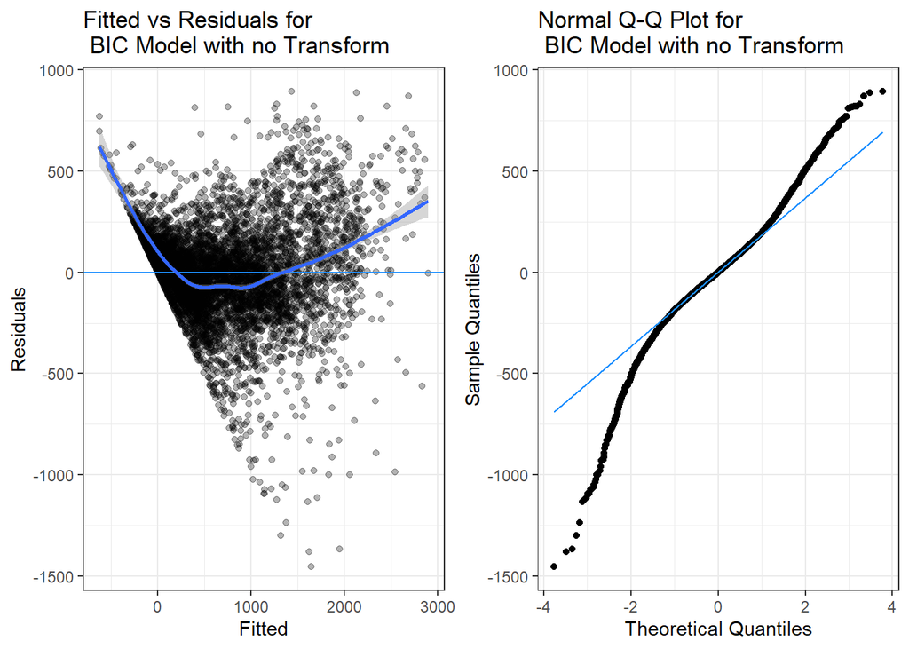

Figure 3.1: Fitted vs Residuals and Q-Q Plot for BIC Model with no Transform

From the Table 3.2 below it is evident that the square root transformation performed the best on the test set with adjusted R2 of 0.902.

Table 3.2: Adjusted R^2 and Test RMSE using power transformations of response variable of BIC model

| Power to Response Variable | Adjusted R^2 | Test RMSE | Proportion of Predictions < 0 in Test Set |
| --- | --- | --- | --- |
| 0.1 | 0.884 | 230.4 | 0.0145 |
| 0.2 | 0.894 | 220.8 | 0.0141 |
| 0.3 | 0.899 | 215.1 | 0.0152 |
| 0.4 | 0.902 | 212.1 | 0.0175 |
| 0.5 | 0.902 | 211.3 | 0.0194 |
| 0.6 | 0.901 | 212.4 | 0.0270 |
| 0.7 | 0.897 | 215.2 | 0.0411 |
| 0.8 | 0.892 | 219.6 | 0.0586 |
| 0.9 | 0.885 | 225.4 | 0.0757 |
| 1.0 | 0.868 | 239.6 | 0.0887 |

The Q-Q plot and Fitted Vs residual plot clearly showed the normalcy and equal variance violations. So, the idea is to transform the response variable, so that the regression residuals become normally-distributed. The optimal lambda value from the Box-Cox power transform is 0.3 but we achieved better RMSE and better adjusted R2 in terms of predictions on the Test set with a lambda = 0.5 which is a square root transformation. Also, since the response variable(Rented Bike Count) is a positive number, we do not have the issue of NaN’s popping due to a negative number raised to 0.5

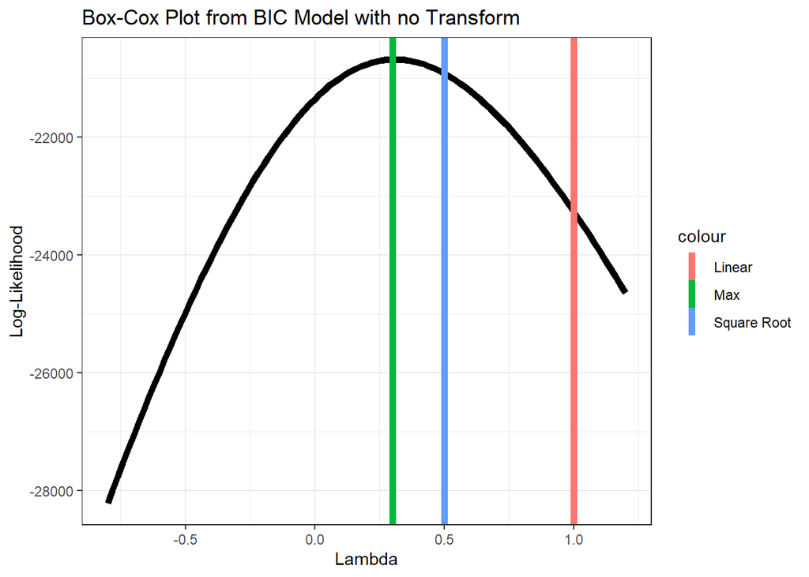

Figure 3.2: Box-Cox Plot from BIC Model with no Transform

The Fitted Vs Residuals plot in Figure 3.3for the best BIC model with square root transform still does not show equal variance and there is no great improvement in the Q-Q plot as it still shows fat tails.

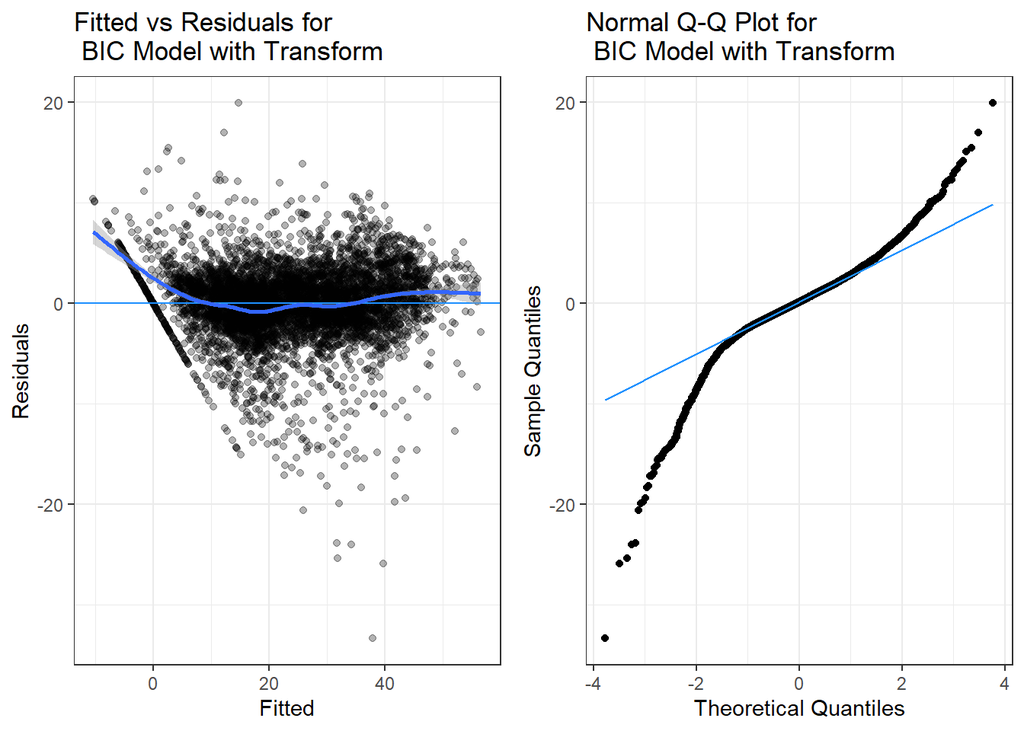

Figure 3.3: Fitted vs Residuals and Q-Q Plot for BIC Model with Sqrt Transform

Table 3.3 below shows the error metrics on the Test set for different models. The BIC of the best model chosen previously greatly reduced after applying a square root transform of the response variable. The square root transform model with manual selection, lets call this the “Selected Model(Sqrt Transform)”, of predictors emerged as the best model with the least error LOOCV-RMSE and least BIC.

Table 3.3: Evaluation of Models (LOOCV-RMSE/BIC of Transformed vs Non-Transformed Not Comparable)

|  | Coefficients | LOOCV-RMSE | BIC | Test RMSE | Adjusted R2 | Test R2 |
| --- | --- | --- | --- | --- | --- | --- |
| All Interaction (Linear) | 214 | 246.9 | 86,002.9 | 241.4 | 0.869 | 0.852 |
| AIC Model (Linear) | 161 | 241.2 | 85,606.2 | 241.4 | 0.870 | 0.852 |
| BIC Model (Linear) | 137 | 240.7 | 85,492.0 | 239.6 | 0.868 | 0.854 |
| BIC Model (Sqrt Transform) | 137 | 4.1 | 35,541.1 | 211.3 | 0.902 | 0.886 |
| Selected Model (Sqrt Transform) | 153 | 3.8 | 34,275.7 | 188.1 | 0.922 | 0.910 |
| Full Model (Sqrt Transform) | 333 | 6.8 | 35,286.9 | 194.7 | 0.926 | 0.904 |

Figure 3.4 and Figure 3.5 show the MAE and RMSE values of the 10 fold Cross Validation of the selected models. It is evident that the Selected Model with square root transform performed the best with the least MAE and RMSE errors.

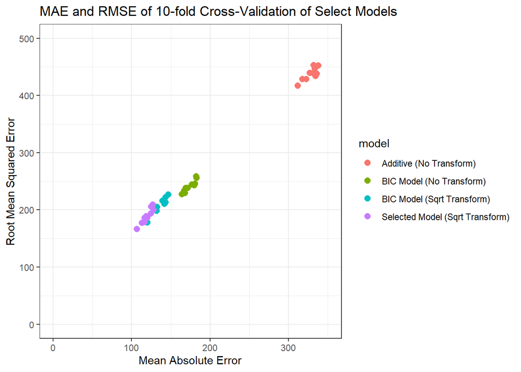

Figure 3.4: Mean Absolute Error and Root Mean Squared Error of 10-fold Cross Validation of Models

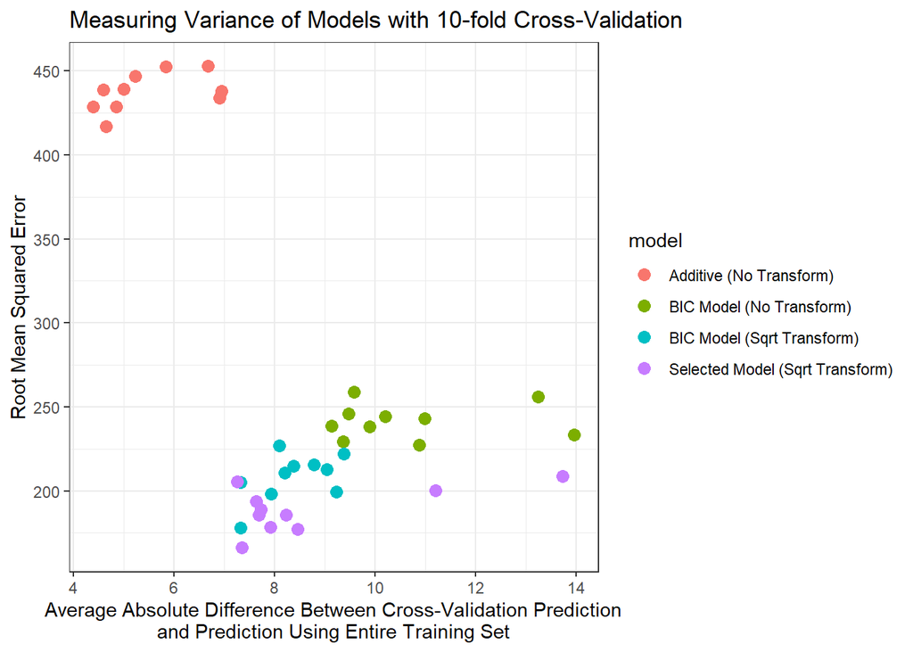

Figure 3.5: Measuring Variance of Models using 10-fold Cross Validation

Table 3.4: Evaluation Metrics of Test Set of Models

|  | Additive Model (No Transform) | BIC Model (No Transform) | BIC Model (Sqrt Transform) | Selected Model (Sqrt Transform) |
| --- | --- | --- | --- | --- |
| Root Mean Squared Error | 418.0 | 239.6 | 211.3 | 188.1 |
| Mean Absolute Error | 318.7 | 170.6 | 134.9 | 116.9 |
| Median Absolute Error | 254.1 | 123.6 | 81.3 | 69.8 |
| Bias | -22.8 | -5.0 | 13.3 | 6.8 |
| Relative Absolute Error | 0.625 | 0.335 | 0.265 | 0.229 |
| Symmetric Mean Absolute Percentage Error | 0.704 | 0.520 | 0.362 | 0.326 |
| Test R-Squared | 0.556 | 0.854 | 0.886 | 0.910 |

Figure 3.6 shows that all the points are closer to the regressed diagonal line and follow the same trend as of the regression line giving us confidence in our predictions.

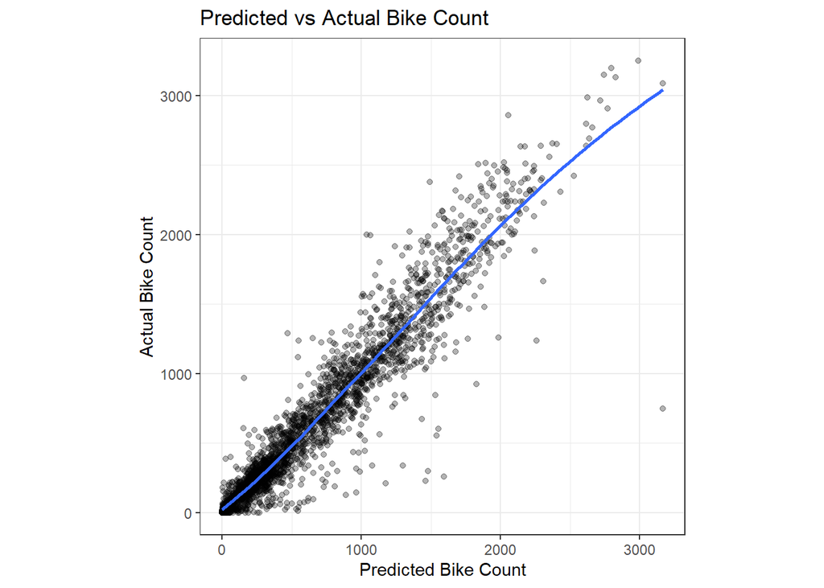

Figure 3.6: Predicted vs Actual Number of Rented Bikes of Test Set using Selected Model (Sqrt Transform)

Figure 3.7 shows the Actuals Vs Errors plotted. Most of the points are densely packed in the lower error regions around 0.

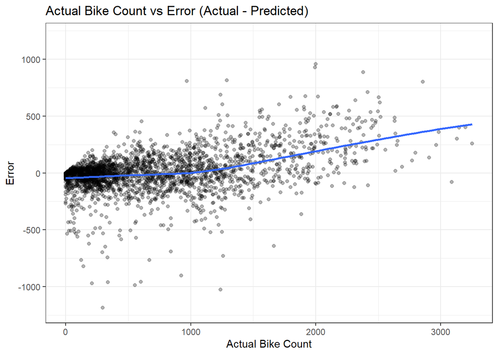

Figure 3.7: Actual Number of Rented Bikes vs Error of Test Set using Selected Model (Sqrt Transform)

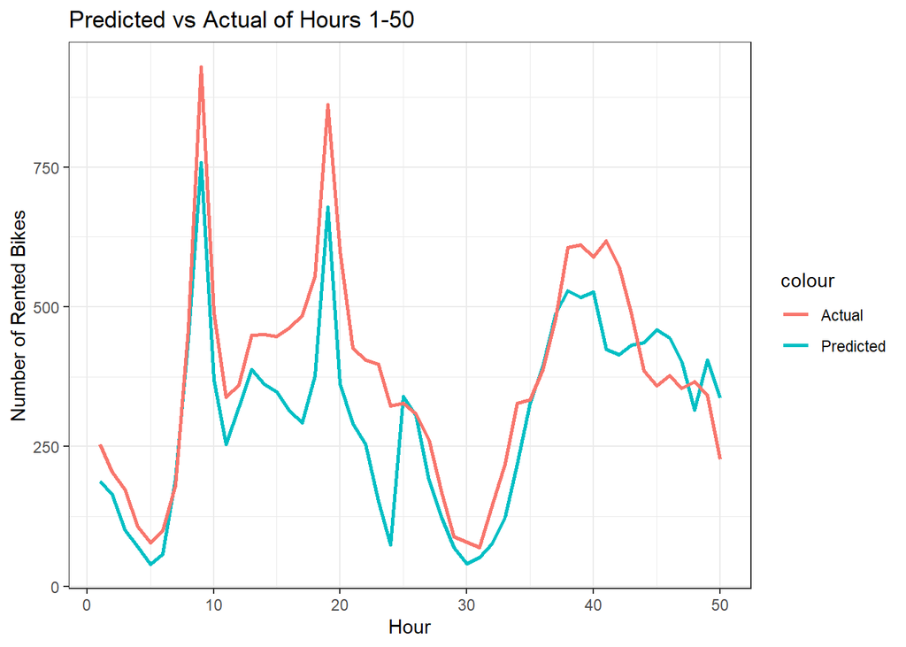

Figure 3.8: Predicted vs Actual Number of Rented Bikes of First 50 Hours of Data

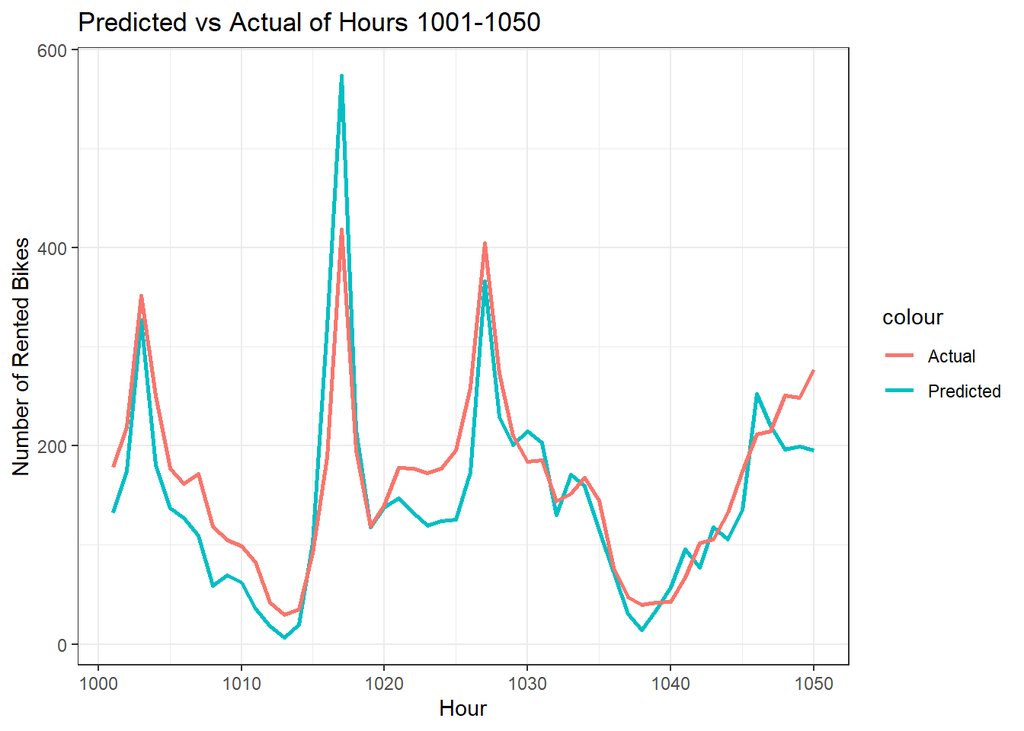

Figure 3.9: Predicted vs Actual Number of Rented Bikes of Hours 1001-1050 of Data

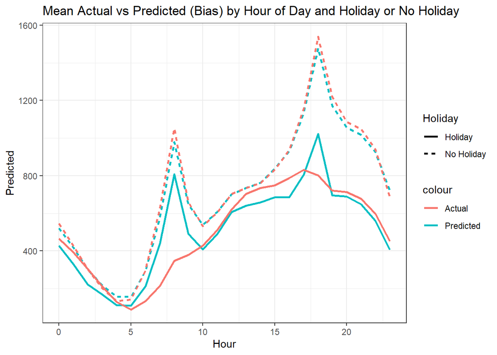

Figure 3.10: Bias of Selected Model for Holidays vs Non-Holidays by Hour

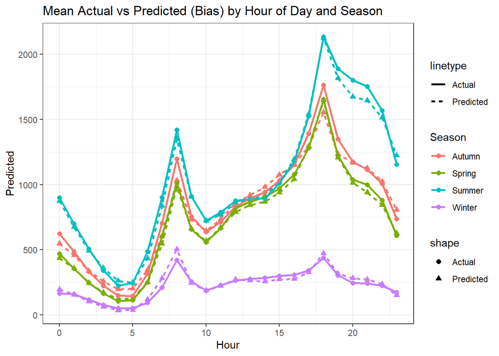

Figure 3.11: Bias of Selected Model by Season and Hour

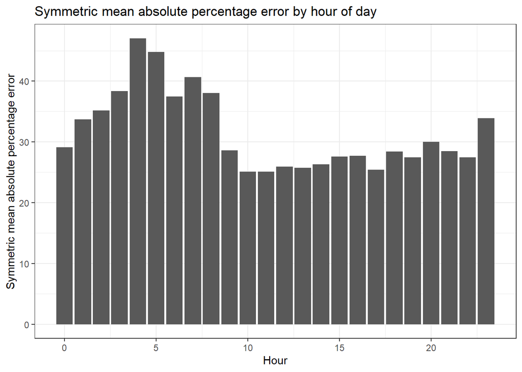

Figure 3.12: Symmetric Mean Percentage Error by Hour of Selected Model

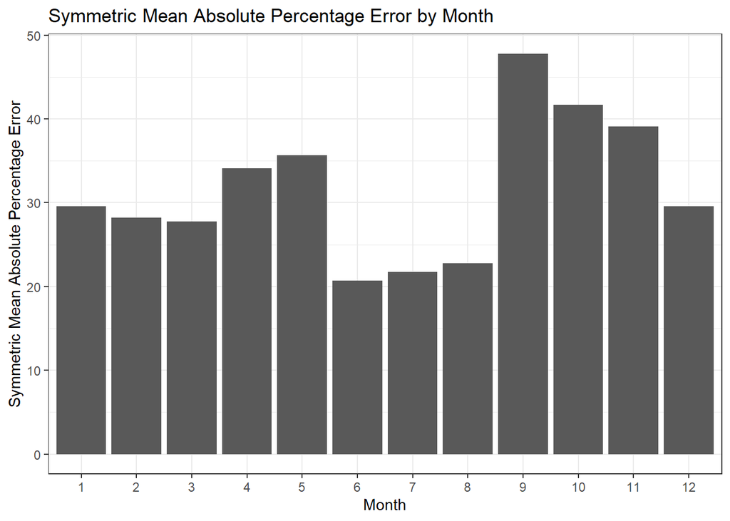

Figure 3.13: Symmetric Mean Percentage Error by Month of Selected Model

# 4 Discussion

Table 3.1 displays the results we received when running the initial models for the data. Starting with a purely additive multiple linear regression model, then adding complexity by including ‘Hour’ as a factor, interactions with ‘Temp’ and ‘Humidity’, and a full two-way interaction model on all predictors within the dataset. The additive model, and subsequent models with limited interactions, performed poorly against the metrics established. Using an ‘All Interaction’ model, which contained all two-way predictor interactions, continued to improve the LOOCV-RMSE, Test RMSE, BIC and $R^2$ metrics at the cost of model complexity, almost doubling the number of coefficients being used. After some trial and error testing, we found the ‘All Interaction’ with quadratics for ‘Wind’ and ‘Temp’ provided even better results. However, a full interaction model with quadratics didn’t yield many significant improvements.

Using the ‘Full Model’, we used a stepwise BIC procedure and manually removed several terms through trial and error to arrive at our best model. We found the ‘Selected Model (Sqrt Transformation)’ that, although increased coefficient complexity, provided the best results for the LOOCV-RMSE, BIC, Test RMSE and Test $R^2$.

# 5 Appendix

Below is code used in the analysis, but cluttered the report. The code is re-printed here, but not evaluated, to show what was used to create, evaluate and select the model. This is primarily the code in the ‘Results’ section for various graphs/tables to illustrate how well the model runs in comparison to the actual data in the ‘Test’ dataset.

```r
table_eval1
```

```r
grid.draw(plot_diag1)
```

```r
table_transform
```

```r
plot_boxcox
```

```r
grid.draw(plot_diag2)
```

```r
table_eval2
```

```r
plot_CV
```

```r
plot_CV2
```

```r
plot_error
```

```r
plot_actual
```

```r
plot_timeline1
```

```r
plot_timeline2
```

```r
plot_hour_holidayerror
```

```r
plot_hour_seasonerror
```

```r
plot_hourerror
```

```r
plot_montherror
```